# Results Summary (Lucid Experiment)

Kyle Peyton

8/2/2018

# Estimated treatment effects

### Primary outcomes

We pre-registered 6 primary outcome measures related to confidence in the doctor’s diagnosis and patient satisfaction:

- `y_confdiag`: How confident are you that this doctor made the correct diagnosis? [not at all confident (1) to completely confident (5)]
- `y_confplan`: How confident are you that this doctor recommended the correct treatment plan? [not at all confident (1) to completely confident (5)]
- `y_whichd`: Which diagnosis do you think is more likely to be correct? [the doctor’s diagnosis (1); online symptom checker (2)]
- `y_askmor`: Would you ask the doctor to perform additional diagnostic tests? (Such as the CT scan recommended by the Symptom Checker). [definitely not (1); probably not (2); might or might not (3); probably (4); definitely (5)]
- `y_satis`: What number would you use to rate your care during this emergency room visit? [0 (worse possible care) to 10 (best possible care)]
- `y_rcmnd`: Would you recommend this doctor to your friends and family? [definitely not (1); probably not (2); might or might not (3); probably (4); definitely (5)]

As specified in our pre-analysis plan, the White Male doctor serves as the control group for all comparisons. For each outcome variable, there are *three estimands*:

1. The ATE of the black male doctor (relative to the white male doctor)
2. The ATE of the black female doctor (relative to the white male doctor)
3. The ATE of the white female doctor (relative to the white male doctor)

The plot below shows the estimated treatment effects (with 95% confidence intervals) on each of the primary outcome measures. The labels on the vertical axis in each facet denote the treatment, and the labels on the horizontal axis denote the estimated treatment effect in standard units (using Glass’s $\Delta$ ). As specified in our pre-analysis plan, estimates are presented using both the simple difference-in-means estimator, and the regression adjusted estimator (adjusting for differences in pre-treatment covariates to improve precision).

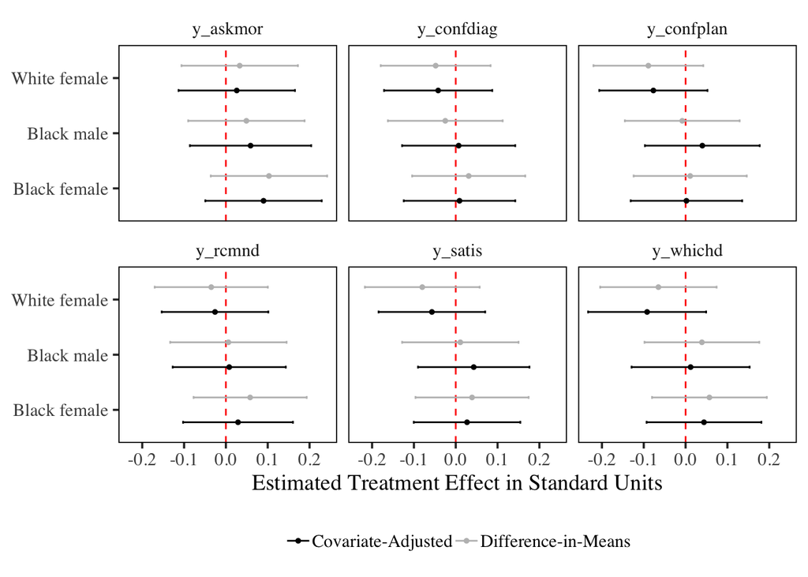

#### Heterogeneity by respondent sex

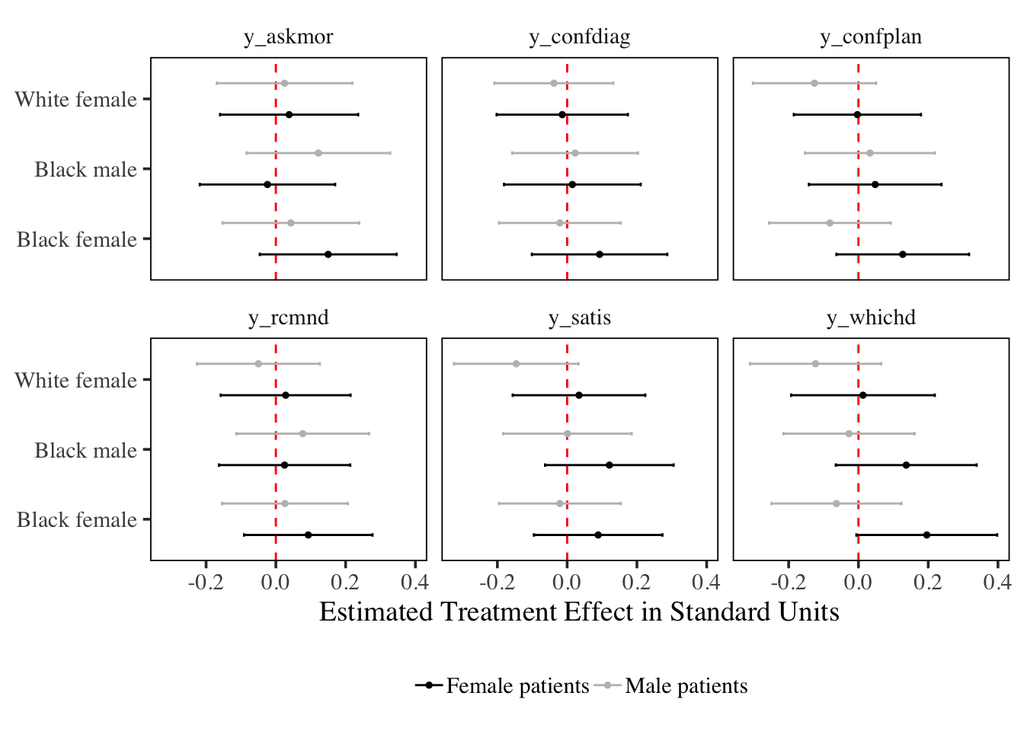

#### Heterogeneity by respondent age

We pre-registered an age cutpoint for individuals born before 1965 versus those born in 1965 or after.

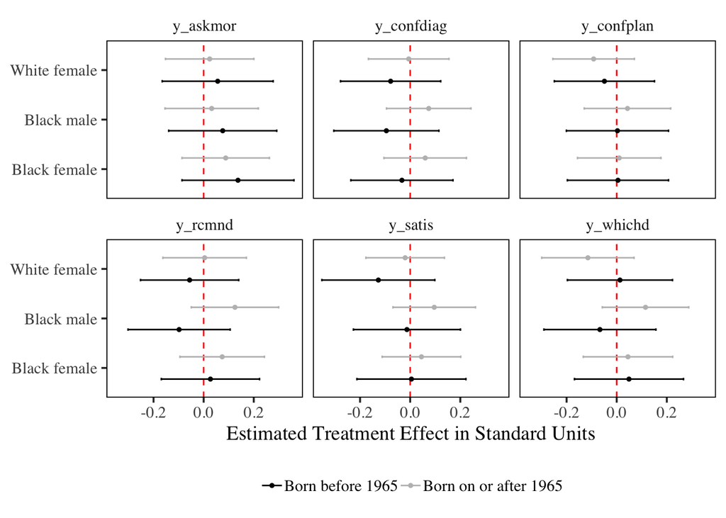

#### Heterogeneity by respondent race

We pre-registered sub-group analyses for black and white respondents. We recruited 191 black respondents (11% of sample) and 1173 white respondents (70% of sample). According to the census, approximately 12% of the US population is black, and about 62% is non-hispanic white. Hispanic/Latino are about 18% of the US population. About 9% of respondents in the Lucid sample were Hispanic/Latino. So Hispanic/Latino were underrepresented, and whites were over-represented. Black respondents were slightly underrepresented (by about 1-2%).

These inferences are not adjusted for multiple comparisons and should be interpreted as suggestive, potentially worth further investigation. There was no evidence of bias among white respondents.

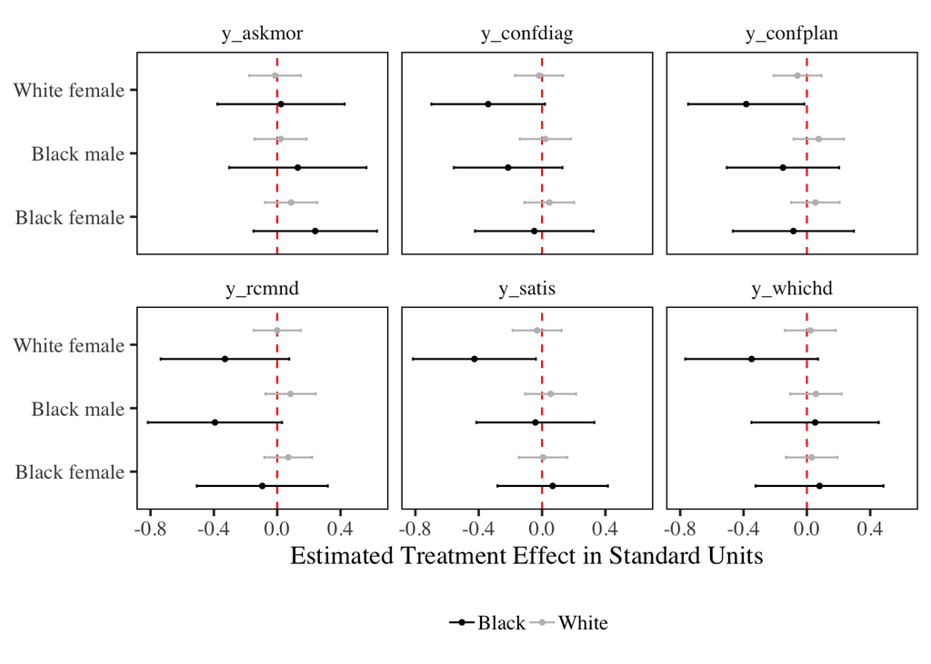

#### Heterogeneity by racial prejudice

We pre-registered sub-group analyses for prejudiced and non-prejudice individuals. Here we use a binary classification scheme. A respondent is deemed an “over racist” if they endorse group-level white supremacy over “blacks” as a group on traits like work-ethic, trustworthiness, etc. Approximately 34% of the sample could be classified as such. Among white respondents, approximately 36% were classified as over racists.

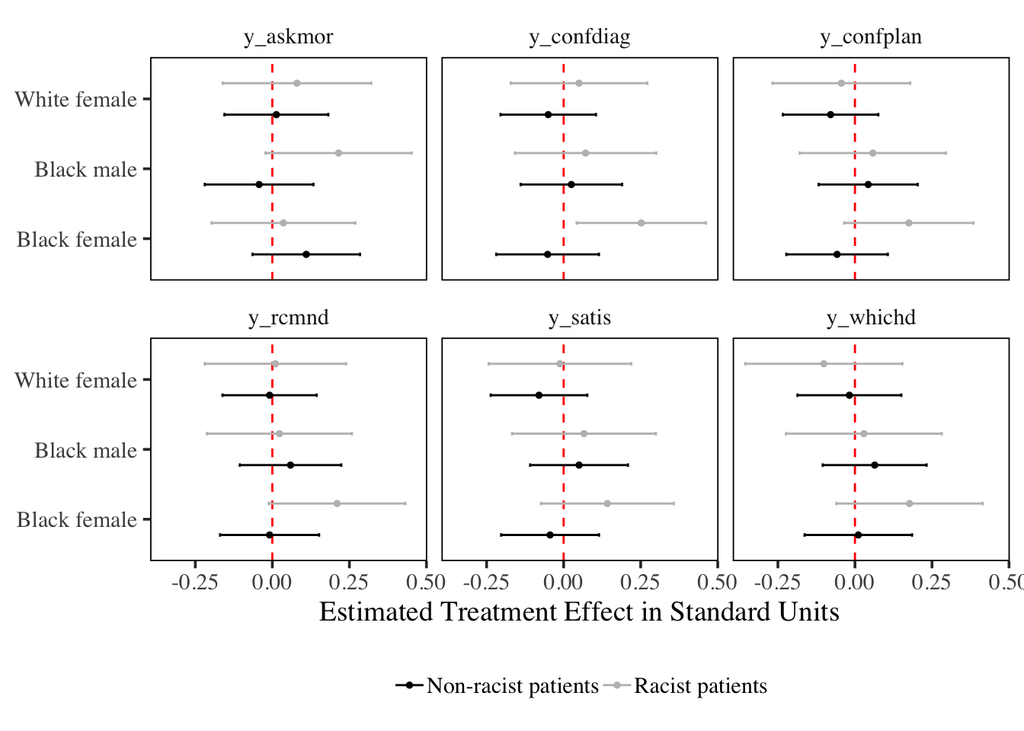

#### Heterogeneity by sexism

We pre-registered sub-group analyses by sexism along two dimensons: benevolent and hostile. We create two indices, one for benevolent sexism and another for hostile sexism so that higher values correspond to higher levels of sexism.

We use randomization inference to test the null hypothesis that all units have a constant effect equal to the estimated ATE (see: http://alexandercoppock.com/ri2/articles/ri2_vignette.html#interaction-terms). First, using the benevolent sexism index, there is very weak evidence of treatment effect heterogeneity. None of the observed test-statistics are statistically significant at conventional levels, for any of the primary outcome measures.

| coefficient | estimate | two_tailed_p_value | null_ci_lower | null_ci_upper | dv |
| --- | --- | --- | --- | --- | --- |
| F-statistic | 0.602 | 0.678 | 0.079 | 3.285 | y_confdiag |
| F-statistic | 0.976 | 0.475 | 0.081 | 3.679 | y_confplan |
| F-statistic | 2.125 | 0.101 | 0.071 | 3.117 | y_whichd |
| F-statistic | 2.524 | 0.089 | 0.081 | 3.439 | y_askmor |
| F-statistic | 0.890 | 0.485 | 0.075 | 3.192 | y_satis |
| F-statistic | 1.188 | 0.341 | 0.091 | 3.498 | y_rcmnd |

Next, we look for effect heterogeneity as a function of hostile sexism. Again, all of the estimates are consistent with the null hypothesis of constant treatment effects. Evidence of effect heterogeneity by hostile sexism is weak.

| coefficient | estimate | two_tailed_p_value | null_ci_lower | null_ci_upper | dv |
| --- | --- | --- | --- | --- | --- |
| F-statistic | 0.359 | 0.802 | 0.085 | 3.215 | y_confdiag |
| F-statistic | 0.092 | 0.978 | 0.096 | 3.393 | y_confplan |
| F-statistic | 0.392 | 0.766 | 0.094 | 3.128 | y_whichd |
| F-statistic | 2.358 | 0.094 | 0.090 | 3.587 | y_askmor |
| F-statistic | 0.132 | 0.950 | 0.066 | 3.317 | y_satis |
| F-statistic | 0.075 | 0.977 | 0.082 | 3.538 | y_rcmnd |

### Secondary outcomes

We pre-registered the following secondary outcome measures:

- `y_scale_comp`: competence dimension of 6-item warmth/competence scale.
- `y_scale_warm`: warmth dimension of 6-item warmth/competence scale

Additionally, the following prompt was added at the end of the patient vignette:

“You take the doctor’s advice and go home. Over the next few days the pain in your abdomen got worse and you returned to the hospital where you were diagnosed with appendicitis. Your appendix had burst and you developed a serious infection. This required an emergency surgery and an extended stay in the hospital’s Intensive Care Unit.”

Respondents were then asked three additional questions:

- `y_error_complain`: Would you file a complaint against this doctor? [(1) Definitely not; (2) Probably not; (3) Might or might not; (4) Probably; (5) Definitely]
- `y_error_sue`: Would you consider suing this doctor? [(1) Definitely not; (2) Probably not; (3) Might or might not; (4) Probably; (5) Definitely]
- `y_error_punitive`: Whether the respondent thought punitive (1) or compensatory (0) damages would be the fairest level of damages against the doctor (if they indicated a desire to sue)

The plot below shows the estimated treatment effects (with 95% confidence intervals) on each of these secondary outcome measures. The labels on the vertical axis in each facet denote the treatment, and the labels on the horizontal axis denote the estimated treatment effect in standard units (using Glass’s $\Delta$). As specified in our pre-analysis plan, estimates are presented using both the simple difference-in-means estimator, and the regression adjusted estimator (adjusting for differences in pre-treatment covariates to improve precision).

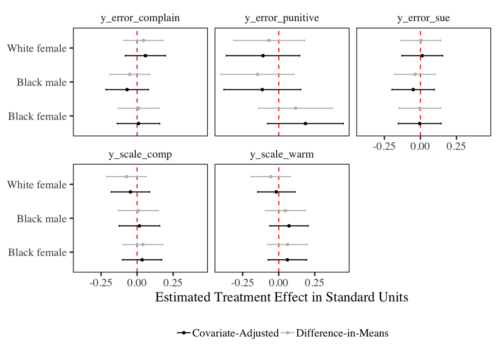

None of the estimates presented above are statistically significant at conventional levels.

In the next five sections, we test for treatment effect heterogeneity among all pre-registered sub-groups for the secondary outcome measures. Again, all estimates are adjusted for pre-treatment trust in doctors.

#### Heterogeneity by respondent sex

There is some weak evidence that female patients are more likely to complain against (and consider suing) female doctors.

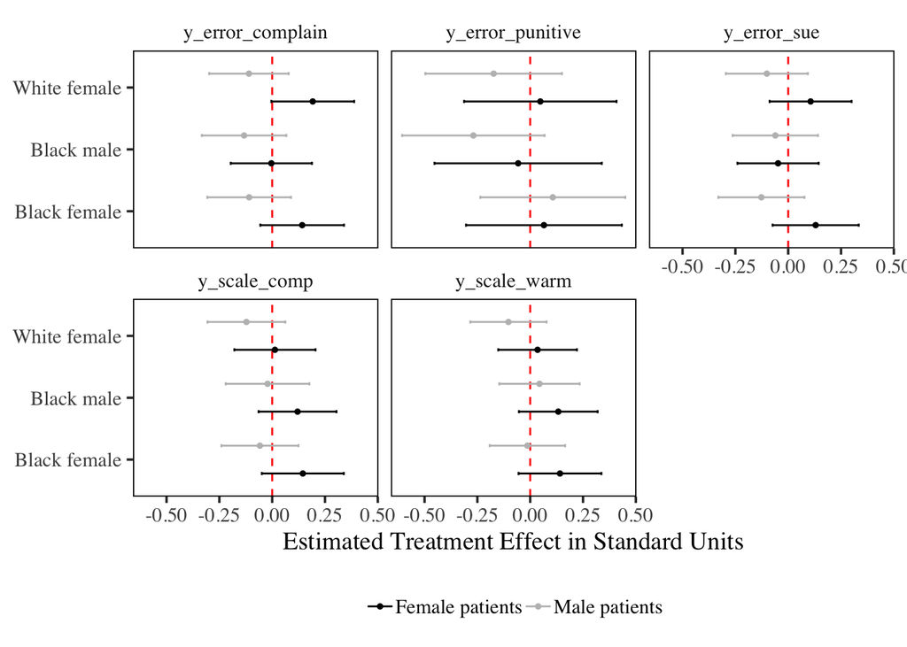

#### Heterogeneity by respondent age

There is some evidence of effect heterogeneity by age. Younger individuals viewed black male doctors as more competent and warm than white male doctors. Older individuals viewed white female doctors and black male doctors as less competent than white male doctors. Again, these inferences must simply be interpreted as “suggestive” given the vast number of comparisons made so far.

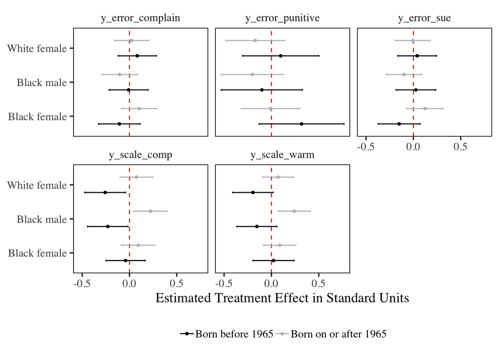

#### Heterogeneity by respondent race

There is some (weak) evidence that black patients who express interest in suing doctors are, on average, less punitive against doctors who are not white men.

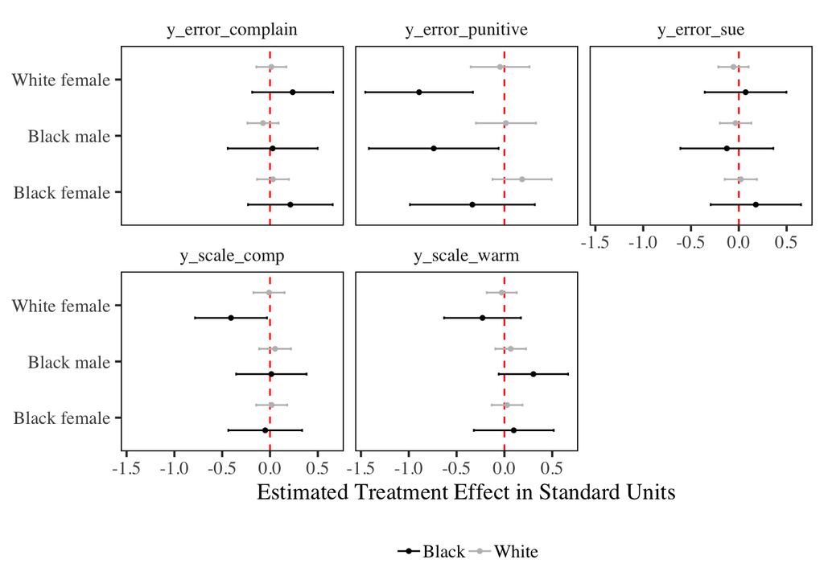

#### Heterogeneity by racial prejudice

Curiously, there is no compelling evidence of differences between racist and non-racist patients. Oddly, racist patients may view black female doctors as more warm and competent than white males. Again, these are noisy estimates and all inferences should be adjusted for multiple comparisons.

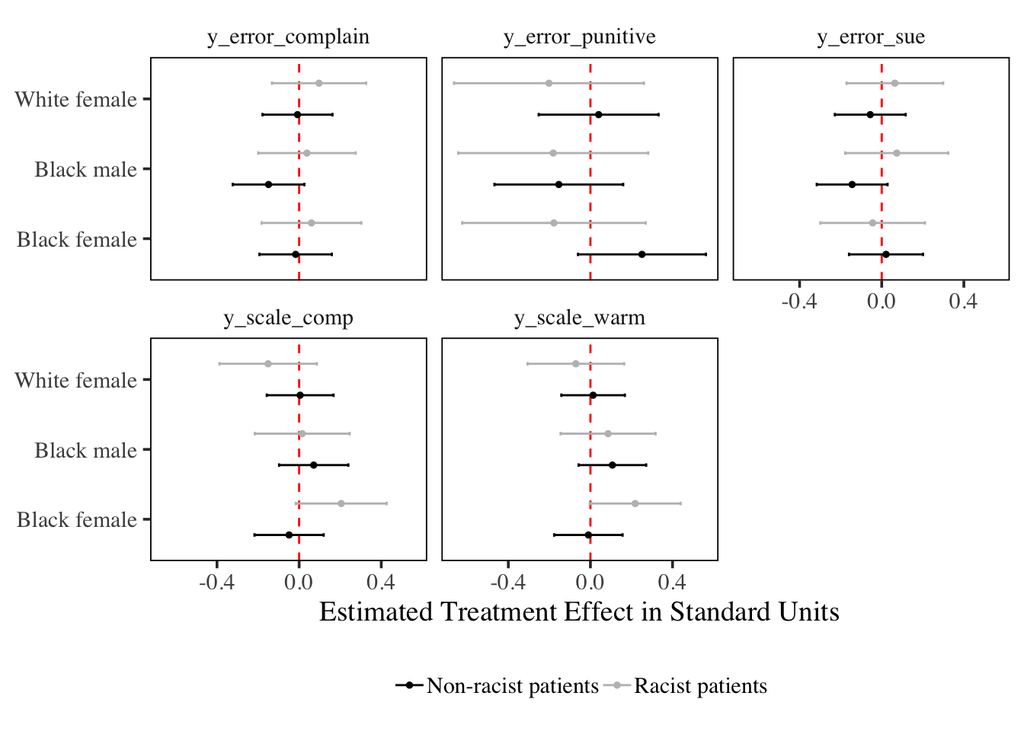

#### Heterogeneity by sexism

There is some (weak) evidence that benevolent sexism explains effect heterogeneity in warm and competence evaluations, as well as likelihood of complaining.

| coefficient | estimate | two_tailed_p_value | null_ci_lower | null_ci_upper | dv |
| --- | --- | --- | --- | --- | --- |
| F-statistic | 2.465 | 0.097 | 0.065 | 3.535 | y_scale_warm |
| F-statistic | 2.968 | 0.069 | 0.102 | 3.739 | y_scale_comp |
| F-statistic | 3.131 | 0.044 | 0.071 | 3.660 | y_error_complain |
| F-statistic | 0.812 | 0.531 | 0.087 | 3.267 | y_error_sue |
| F-statistic | 0.438 | 0.717 | 0.065 | 2.986 | y_error_punitive |

Next, we look for effect heterogeneity as a function of hostile sexism. Again, all of the estimates are consistent with the null hypothesis of constant treatment effects. Evidence of effect heterogeneity by hostile sexism is remarkably weak.

| coefficient | estimate | two_tailed_p_value | null_ci_lower | null_ci_upper | dv |
| --- | --- | --- | --- | --- | --- |
| F-statistic | 0.621 | 0.669 | 0.100 | 3.903 | y_scale_warm |
| F-statistic | 0.799 | 0.613 | 0.097 | 3.773 | y_scale_comp |
| F-statistic | 0.676 | 0.639 | 0.072 | 3.626 | y_error_complain |
| F-statistic | 1.423 | 0.217 | 0.060 | 2.816 | y_error_sue |
| F-statistic | 1.500 | 0.207 | 0.066 | 2.885 | y_error_punitive |